# Ford GoBike System Data

### What is the structure of your dataset?

> The dataset recorded Ford GoBike's bike-sharing service in the greater SF Bay area. Each record is an individual ride which consists of 16 features, such as duration, ride start/end time, start and end station id/name, start/end station coordinates, bikes id, user type, member birth year, member age, gender, and bike share for all trips. For this analysis I have selectected one year period from 2018-05 until 2019-04, that contains 2,161,106 bike trips.

### What is/are the main feature(s) of interest in your dataset?

> - When are most trips taken in terms of time of hour, weekday or month of the year?
> - Who are the customers of Ford GoBikes by age, gender and type?
> - How do the bike trips usually look by trip duration, distance and speed?

### What features in the dataset do you think will help support your investigation into your feature(s) of interest?

> I will be concentrated on three groups of features, such as TIME (hours, weekdays, moths), USER (age, gender, type) and TRAVEL (duration, distance, speed).

## Data Wrangling and creating new variables

- Convert the duration in seconds to minutes
- Delete values where the station id is null
- Convert the end and start station id to int
- Convert the Start time and End time to timestamps
- Get the start time hour from start time
- Divide the start_time and end_time to separated columns start_date, start_time, end_date and end_date
- Extract the month column from start date
- Get the weekdays column from start time
- Get customer age on the trip day
- Calculate approx trip duration by latitude and longtitude
- Calculate approx trip speed km/h
- Create users age groups column
- Drop unneccassary variables
- Create cleaned and adjusted new csv file

```python
# code
ford_gobike['duration_min']= ford_gobike['duration_sec']/60
ford_gobike['duration_min']= ford_gobike['duration_min'].astype(float)
# test
ford_gobike.head()
```

|  | duration_sec | start_time | end_time | start_station_id | start_station_name | start_station_latitude | start_station_longitude | end_station_id | end_station_name | end_station_latitude | end_station_longitude | bike_id | user_type | member_birth_year | member_gender | bike_share_for_all_trip | duration_min |
| --- | --- | --- | --- | --- | --- | --- | --- | --- | --- | --- | --- | --- | --- | --- | --- | --- | --- |
| 1 | 42847 | 2018-11-30 20:13:45.5090 | 2018-12-01 08:07:53.1330 | 37.0 | 2nd St at Folsom St | 37.785000 | -122.395936 | 30.0 | San Francisco Caltrain (Townsend St at 4th St) | 37.776598 | -122.395282 | 2614 | Customer | 1992.0 | Male | No | 714.116667 |
| 2 | 1128 | 2018-11-30 23:58:26.4310 | 2018-12-01 00:17:14.4880 | 249.0 | Russell St at College Ave | 37.858473 | -122.253253 | 249.0 | Russell St at College Ave | 37.858473 | -122.253253 | 1496 | Subscriber | 1998.0 | Male | Yes | 18.800000 |
| 3 | 2476 | 2018-11-30 23:35:06.7230 | 2018-12-01 00:16:23.4740 | 104.0 | 4th St at 16th St | 37.767045 | -122.390833 | 15.0 | San Francisco Ferry Building (Harry Bridges Pl... | 37.795392 | -122.394203 | 1334 | Subscriber | 1959.0 | Male | No | 41.266667 |
| 4 | 1273 | 2018-11-30 23:54:12.3890 | 2018-12-01 00:15:26.3680 | 44.0 | Civic Center/UN Plaza BART Station (Market St ... | 37.781074 | -122.411738 | 60.0 | 8th St at Ringold St | 37.774520 | -122.409449 | 393 | Subscriber | 1993.0 | Female | Yes | 21.216667 |
| 5 | 2264 | 2018-11-30 23:32:51.3200 | 2018-12-01 00:10:35.8310 | 92.0 | Mission Bay Kids Park | 37.772301 | -122.393028 | 34.0 | Father Alfred E Boeddeker Park | 37.783988 | -122.412408 | 4377 | Subscriber | 1972.0 | Male | Yes | 37.733333 |

##### Delete values where the station id is null

```python
# code
ford_gobike[ford_gobike['start_station_id'].isna()]
ford_gobike.dropna(subset = ['start_station_id'], inplace=True)
# test
ford_gobike[ford_gobike['start_station_id'].isna()]
```

|  | duration_sec | start_time | end_time | start_station_id | start_station_name | start_station_latitude | start_station_longitude | end_station_id | end_station_name | end_station_latitude | end_station_longitude | bike_id | user_type | member_birth_year | member_gender | bike_share_for_all_trip | duration_min |
| --- | --- | --- | --- | --- | --- | --- | --- | --- | --- | --- | --- | --- | --- | --- | --- | --- | --- |

##### Convert the Start time and End time to timestamps

```python
# code
ford_gobike.start_time = pd.to_datetime(ford_gobike.start_time)
ford_gobike.end_time = pd.to_datetime(ford_gobike.start_time)
#test
ford_gobike.info()
```

```
<class 'pandas.core.frame.DataFrame'>
Int64Index: 2161106 entries, 1 to 2290553
Data columns (total 17 columns):
 #   Column                   Dtype
---  ------                   -----
 0   duration_sec             int64
 1   start_time               datetime64[ns]
 2   end_time                 datetime64[ns]
 3   start_station_id         float64
 4   start_station_name       object
 5   start_station_latitude   float64
 6   start_station_longitude  float64
 7   end_station_id           float64
 8   end_station_name         object
 9   end_station_latitude     float64
 10  end_station_longitude    float64
 11  bike_id                  int64
 12  user_type                object
 13  member_birth_year        float64
 14  member_gender            object
 15  bike_share_for_all_trip  object
 16  duration_min             float64
dtypes: datetime64[ns](2), float64(8), int64(2), object(5)
memory usage: 296.8+ MB
```

##### Get the start time hour from start time

```python
# code
ford_gobike['start_hour'] = ford_gobike['start_time'].dt.hour
# test
ford_gobike['start_hour'].unique()
```

```
array([20, 23, 21, 22, 19, 18, 17, 16, 15, 10, 14, 11, 13, 12,  9,  8,  7,
        6,  5,  4,  3,  2,  1,  0])
```

##### Divide the start_time and end_time to separated columns start_date, start_time, end_date and end_date

```python
# code
ford_gobike['start_date'] = pd.to_datetime(ford_gobike['start_time']).dt.date
ford_gobike['start_time'] = pd.to_datetime(ford_gobike['start_time']).dt.time
# test
ford_gobike.head()
```

|  | duration_sec | start_time | end_time | start_station_id | start_station_name | start_station_latitude | start_station_longitude | end_station_id | end_station_name | end_station_latitude | end_station_longitude | bike_id | user_type | member_birth_year | member_gender | bike_share_for_all_trip | duration_min | start_hour | start_date |
| --- | --- | --- | --- | --- | --- | --- | --- | --- | --- | --- | --- | --- | --- | --- | --- | --- | --- | --- | --- |
| 1 | 42847 | 20:13:45.509000 | 2018-11-30 20:13:45.509 | 37.0 | 2nd St at Folsom St | 37.785000 | -122.395936 | 30.0 | San Francisco Caltrain (Townsend St at 4th St) | 37.776598 | -122.395282 | 2614 | Customer | 1992.0 | Male | No | 714.116667 | 20 | 2018-11-30 |
| 2 | 1128 | 23:58:26.431000 | 2018-11-30 23:58:26.431 | 249.0 | Russell St at College Ave | 37.858473 | -122.253253 | 249.0 | Russell St at College Ave | 37.858473 | -122.253253 | 1496 | Subscriber | 1998.0 | Male | Yes | 18.800000 | 23 | 2018-11-30 |
| 3 | 2476 | 23:35:06.723000 | 2018-11-30 23:35:06.723 | 104.0 | 4th St at 16th St | 37.767045 | -122.390833 | 15.0 | San Francisco Ferry Building (Harry Bridges Pl... | 37.795392 | -122.394203 | 1334 | Subscriber | 1959.0 | Male | No | 41.266667 | 23 | 2018-11-30 |
| 4 | 1273 | 23:54:12.389000 | 2018-11-30 23:54:12.389 | 44.0 | Civic Center/UN Plaza BART Station (Market St ... | 37.781074 | -122.411738 | 60.0 | 8th St at Ringold St | 37.774520 | -122.409449 | 393 | Subscriber | 1993.0 | Female | Yes | 21.216667 | 23 | 2018-11-30 |
| 5 | 2264 | 23:32:51.320000 | 2018-11-30 23:32:51.320 | 92.0 | Mission Bay Kids Park | 37.772301 | -122.393028 | 34.0 | Father Alfred E Boeddeker Park | 37.783988 | -122.412408 | 4377 | Subscriber | 1972.0 | Male | Yes | 37.733333 | 23 | 2018-11-30 |

##### Extract the month column from start date

```python
# code
ford_gobike['start_date2'] =  pd.to_datetime(ford_gobike['start_date'], format='%Y-%m-%d')
ford_gobike['start_year'] = ford_gobike['start_date2'].apply(lambda r:r.year).astype(int)
ford_gobike['start_month'] = ford_gobike['start_date2'].apply(lambda r:r.month).astype(int)
# test
ford_gobike.head()
```

|  | duration_sec | start_time | end_time | start_station_id | start_station_name | start_station_latitude | start_station_longitude | end_station_id | end_station_name | end_station_latitude | ... | user_type | member_birth_year | member_gender | bike_share_for_all_trip | duration_min | start_hour | start_date | start_date2 | start_year | start_month |
| --- | --- | --- | --- | --- | --- | --- | --- | --- | --- | --- | --- | --- | --- | --- | --- | --- | --- | --- | --- | --- | --- |
| 1 | 42847 | 20:13:45.509000 | 2018-11-30 20:13:45.509 | 37.0 | 2nd St at Folsom St | 37.785000 | -122.395936 | 30.0 | San Francisco Caltrain (Townsend St at 4th St) | 37.776598 | ... | Customer | 1992.0 | Male | No | 714.116667 | 20 | 2018-11-30 | 2018-11-30 | 2018 | 11 |
| 2 | 1128 | 23:58:26.431000 | 2018-11-30 23:58:26.431 | 249.0 | Russell St at College Ave | 37.858473 | -122.253253 | 249.0 | Russell St at College Ave | 37.858473 | ... | Subscriber | 1998.0 | Male | Yes | 18.800000 | 23 | 2018-11-30 | 2018-11-30 | 2018 | 11 |
| 3 | 2476 | 23:35:06.723000 | 2018-11-30 23:35:06.723 | 104.0 | 4th St at 16th St | 37.767045 | -122.390833 | 15.0 | San Francisco Ferry Building (Harry Bridges Pl... | 37.795392 | ... | Subscriber | 1959.0 | Male | No | 41.266667 | 23 | 2018-11-30 | 2018-11-30 | 2018 | 11 |
| 4 | 1273 | 23:54:12.389000 | 2018-11-30 23:54:12.389 | 44.0 | Civic Center/UN Plaza BART Station (Market St ... | 37.781074 | -122.411738 | 60.0 | 8th St at Ringold St | 37.774520 | ... | Subscriber | 1993.0 | Female | Yes | 21.216667 | 23 | 2018-11-30 | 2018-11-30 | 2018 | 11 |
| 5 | 2264 | 23:32:51.320000 | 2018-11-30 23:32:51.320 | 92.0 | Mission Bay Kids Park | 37.772301 | -122.393028 | 34.0 | Father Alfred E Boeddeker Park | 37.783988 | ... | Subscriber | 1972.0 | Male | Yes | 37.733333 | 23 | 2018-11-30 | 2018-11-30 | 2018 | 11 |

5 rows × 22 columns

##### Get the weekdays column from start time

```python
# code
ford_gobike['start_weekday'] = ford_gobike.start_date2.dt.strftime('%a')
# test
ford_gobike['start_weekday'].unique()
```

```
array(['Fri', 'Thu', 'Wed', 'Tue', 'Mon', 'Sun', 'Sat'], dtype=object)
```

##### Get customer age on the trip day

```python
# code
ford_gobike['user_age'] = ford_gobike['start_year'] - ford_gobike['member_birth_year']
ford_gobike['user_age'] = ford_gobike['user_age'].astype(int)
# test
ford_gobike.head()
```

|  | duration_sec | start_time | end_time | start_station_id | start_station_name | start_station_latitude | start_station_longitude | end_station_id | end_station_name | end_station_latitude | ... | member_gender | bike_share_for_all_trip | duration_min | start_hour | start_date | start_date2 | start_year | start_month | start_weekday | user_age |
| --- | --- | --- | --- | --- | --- | --- | --- | --- | --- | --- | --- | --- | --- | --- | --- | --- | --- | --- | --- | --- | --- |
| 1 | 42847 | 20:13:45.509000 | 2018-11-30 20:13:45.509 | 37.0 | 2nd St at Folsom St | 37.785000 | -122.395936 | 30.0 | San Francisco Caltrain (Townsend St at 4th St) | 37.776598 | ... | Male | No | 714.116667 | 20 | 2018-11-30 | 2018-11-30 | 2018 | 11 | Fri | 26 |
| 2 | 1128 | 23:58:26.431000 | 2018-11-30 23:58:26.431 | 249.0 | Russell St at College Ave | 37.858473 | -122.253253 | 249.0 | Russell St at College Ave | 37.858473 | ... | Male | Yes | 18.800000 | 23 | 2018-11-30 | 2018-11-30 | 2018 | 11 | Fri | 20 |
| 3 | 2476 | 23:35:06.723000 | 2018-11-30 23:35:06.723 | 104.0 | 4th St at 16th St | 37.767045 | -122.390833 | 15.0 | San Francisco Ferry Building (Harry Bridges Pl... | 37.795392 | ... | Male | No | 41.266667 | 23 | 2018-11-30 | 2018-11-30 | 2018 | 11 | Fri | 59 |
| 4 | 1273 | 23:54:12.389000 | 2018-11-30 23:54:12.389 | 44.0 | Civic Center/UN Plaza BART Station (Market St ... | 37.781074 | -122.411738 | 60.0 | 8th St at Ringold St | 37.774520 | ... | Female | Yes | 21.216667 | 23 | 2018-11-30 | 2018-11-30 | 2018 | 11 | Fri | 25 |
| 5 | 2264 | 23:32:51.320000 | 2018-11-30 23:32:51.320 | 92.0 | Mission Bay Kids Park | 37.772301 | -122.393028 | 34.0 | Father Alfred E Boeddeker Park | 37.783988 | ... | Male | Yes | 37.733333 | 23 | 2018-11-30 | 2018-11-30 | 2018 | 11 | Fri | 46 |

5 rows × 24 columns

##### Create users age groups column

```python
# code
pd.DataFrame(ford_gobike, columns=['user_age'])

bins = [18, 23, 28, 33, 38, 43, 48, 53, 58, 63, 68, 73, 78, 83]
labels = ['18-22', '23-27', '28-32', '33-37', '38-42', '43-47', '48-52', '53-57', '58-62', '63-67', '68-72', '73-77', '78+']
ford_gobike['age_range'] = pd.cut(ford_gobike.user_age, bins, labels = labels,include_lowest = True)
```

```python
#test
ford_gobike.head()
```

|  | duration_sec | start_time | end_time | start_station_id | start_station_name | start_station_latitude | start_station_longitude | end_station_id | end_station_name | end_station_latitude | ... | bike_share_for_all_trip | duration_min | start_hour | start_date | start_date2 | start_year | start_month | start_weekday | user_age | age_range |
| --- | --- | --- | --- | --- | --- | --- | --- | --- | --- | --- | --- | --- | --- | --- | --- | --- | --- | --- | --- | --- | --- |
| 1 | 42847 | 20:13:45.509000 | 2018-11-30 20:13:45.509 | 37.0 | 2nd St at Folsom St | 37.785000 | -122.395936 | 30.0 | San Francisco Caltrain (Townsend St at 4th St) | 37.776598 | ... | No | 714.116667 | 20 | 2018-11-30 | 2018-11-30 | 2018 | 11 | Fri | 26 | 23-27 |
| 2 | 1128 | 23:58:26.431000 | 2018-11-30 23:58:26.431 | 249.0 | Russell St at College Ave | 37.858473 | -122.253253 | 249.0 | Russell St at College Ave | 37.858473 | ... | Yes | 18.800000 | 23 | 2018-11-30 | 2018-11-30 | 2018 | 11 | Fri | 20 | 18-22 |
| 3 | 2476 | 23:35:06.723000 | 2018-11-30 23:35:06.723 | 104.0 | 4th St at 16th St | 37.767045 | -122.390833 | 15.0 | San Francisco Ferry Building (Harry Bridges Pl... | 37.795392 | ... | No | 41.266667 | 23 | 2018-11-30 | 2018-11-30 | 2018 | 11 | Fri | 59 | 58-62 |
| 4 | 1273 | 23:54:12.389000 | 2018-11-30 23:54:12.389 | 44.0 | Civic Center/UN Plaza BART Station (Market St ... | 37.781074 | -122.411738 | 60.0 | 8th St at Ringold St | 37.774520 | ... | Yes | 21.216667 | 23 | 2018-11-30 | 2018-11-30 | 2018 | 11 | Fri | 25 | 23-27 |
| 5 | 2264 | 23:32:51.320000 | 2018-11-30 23:32:51.320 | 92.0 | Mission Bay Kids Park | 37.772301 | -122.393028 | 34.0 | Father Alfred E Boeddeker Park | 37.783988 | ... | Yes | 37.733333 | 23 | 2018-11-30 | 2018-11-30 | 2018 | 11 | Fri | 46 | 43-47 |

5 rows × 25 columns

```python
# code
def distance_calculation(ford_gobike):
    #Thus, the implied "official" circumference is 360 degrees times 60 minutes/degree times 1.852 km/minute = 40003.2 km. The implied radius is the circumference divided by 2 pi: R = 6367 km
    R = 6373.0

    lat1 = radians(ford_gobike['start_station_latitude'])
    lon1 = radians(ford_gobike['start_station_longitude'])
    lat2 = radians(ford_gobike['end_station_latitude'])
    lon2 = radians(ford_gobike['end_station_longitude'])

# using Deriving the Haversine Formula
    dlon = lon2 - lon1
    dlat = lat2 - lat1
    a = (sin(dlat/2))**2 + cos(lat1) * cos(lat2) * (sin(dlon/2))**2
    c = 2 * atan2(sqrt(a), sqrt(1-a))
    return R * c

ford_gobike['distance'] = ford_gobike.apply(distance_calculation, axis=1)
```

```python
(ford_gobike.distance ==0).sum()
```

```
51969
```

```python
ford_gobike = ford_gobike[ford_gobike.distance !=0]
```

```python
# test
ford_gobike['distance'].describe()
```

```
count    2.109137e+06
mean     1.800562e+00
std      3.842420e+01
min      1.329149e-02
25%      9.279180e-01
50%      1.426658e+00
75%      2.173342e+00
max      1.280236e+04
Name: distance, dtype: float64
```

##### Calculate approx trip speed km/h

```python
# code
ford_gobike['speed km/h'] = round(ford_gobike['distance']/(ford_gobike['duration_min']/60),2)
```

```python
# test
ford_gobike['speed km/h'].value_counts()
```

```
11.17    2842
10.56    2817
9.96     2817
9.77     2812
10.06    2812
         ...
26.01       1
26.49       1
26.26       1
26.51       1
27.66       1
Name: speed km/h, Length: 2562, dtype: int64
```

##### Drop unneccassary variables

```python
ford_gobike.drop(columns = ['bike_share_for_all_trip','end_time',
                 'start_station_id','end_station_id',
                'start_station_latitude', 'start_station_longitude', 'end_station_latitude',
                 'end_station_longitude', 'start_date', 'bike_id',
                 'start_station_name', 'end_station_name', 'member_birth_year'], inplace=True, axis=1)
```

```python
# test
ford_gobike.info()
```

```
<class 'pandas.core.frame.DataFrame'>
Int64Index: 2109137 entries, 1 to 2290553
Data columns (total 14 columns):
 #   Column         Dtype
---  ------         -----
 0   duration_sec   int64
 1   start_time     object
 2   user_type      object
 3   member_gender  object
 4   duration_min   float64
 5   start_hour     int64
 6   start_date2    datetime64[ns]
 7   start_year     int64
 8   start_month    int64
 9   start_weekday  object
 10  user_age       int64
 11  age_range      category
 12  distance       float64
 13  speed km/h     float64
dtypes: category(1), datetime64[ns](1), float64(3), int64(5), object(4)
memory usage: 227.3+ MB
```

##### Create cleaned and adjusted new csv file

```python
# code
ford_gobike.to_csv('fordgo_final.csv', index = False)
```

## Univariate Exploration

> In this section, investigate distributions of individual variables.

### Exploration of TIME variables

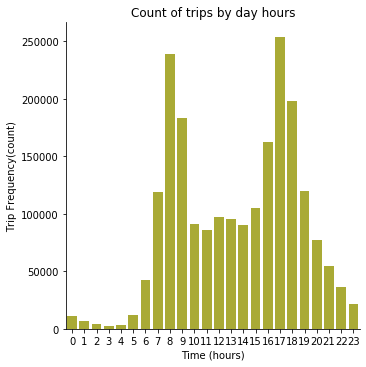

```python
sb.catplot(data=ford_gobike, x='start_hour', kind='count', color = sb.color_palette()[8])
plt.title('Count of trips by day hours')
plt.xlabel('Time (hours)')
plt.ylabel('Trip Frequency(count)')
plt.show();
```

> Trip start hour distribution looks roughly bimodal, with one peak between 7 and 9 hours, and a second peak between 16 and 19 hour which are a little higher. It shows that bikes are used before and after the working hour. Customers used bikes to travel to work and back.

Next up, the trip distribution on weekdays.

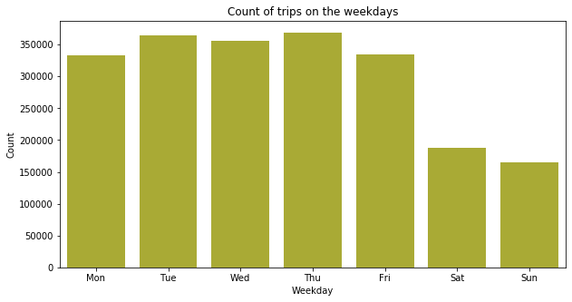

```python
plt.figure(figsize=[10, 5])
order_d = ['Mon', 'Tue', 'Wed', 'Thu', 'Fri', 'Sat', 'Sun']
sb.countplot(data=ford_gobike, x='start_weekday', color = sb.color_palette()[8], order = order_d);
plt.title('Count of trips on the weekdays')
plt.xlabel('Weekday')
plt.ylabel('Count')
plt.show();
```

> Trip start weekday distributions are similar on working days but on weekends are followed down almost twice. The visualisation below proves that customers use bikes mostly on weekdays.

Next up, the trip distribution by monthly.

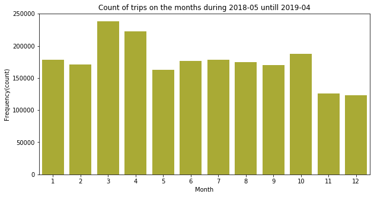

```python
plt.figure(figsize=[10, 5])
sb.countplot(data=ford_gobike, x='start_month', color = sb.color_palette()[8]);
plt.title('Count of trips on the months during 2018-05 untill 2019-04')
plt.xlabel('Month')
plt.ylabel('Frequency(count)')
plt.show();
```

> Trip count on start month distribution is highest in March, April and October and lowest in November and December.

Next below, all three plots displayed together.

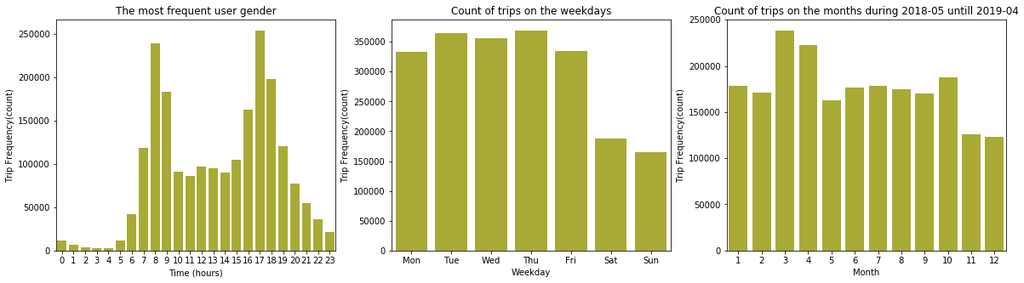

```python
plt.figure(figsize = [20, 5])

plt.subplot(1, 3, 1)
sb.countplot(data=ford_gobike, x='start_hour', color = sb.color_palette()[8]);
plt.title('The most frequent user gender')
plt.xlabel('Time (hours)')
plt.ylabel('Trip Frequency(count)')

plt.subplot(1, 3, 2)
order_d = ['Mon', 'Tue', 'Wed', 'Thu', 'Fri', 'Sat', 'Sun']
sb.countplot(data=ford_gobike, x='start_weekday', color = sb.color_palette()[8], order = order_d);
plt.title('Count of trips on the weekdays')
plt.xlabel('Weekday')
plt.ylabel('Trip Frequency(count)')

plt.subplot(1, 3, 3)
sb.countplot(data=ford_gobike, x='start_month', color = sb.color_palette()[8]);
plt.title('Count of trips on the months during 2018-05 untill 2019-04')
plt.xlabel('Month')
plt.ylabel('Trip Frequency(count)')
plt.show();
```

> From the above figure plots we can make final trip frequency distribution by time variables. So we could say that the most customers use bikes at 8 and 17 hour, during workdays and in March and April months.

Next up, exploration of Customer variables.

### Exploration of USER variables

```python
pd.set_option('display.max_rows', 1000)
ford_gobike['user_age'].value_counts()
```

```
30     120591
31     112223
29     104386
28     102789
27      97012
25      96681
26      95346
32      95053
33      93856
34      83654
24      82194
35      77802
36      71820
23      63780
37      60224
```

[output cut: 81 more lines]

> For user age, there are some false ages provided as there are ages until 141 years. I will eliminate the ages who are 2.5 times higher than the mean.

```python
# dropping false age entries
ford_gobike = ford_gobike.drop(ford_gobike.index[(ford_gobike['user_age'] > (2.5*ford_gobike['user_age'].mean()))])
```

```python
# review current age values
ford_gobike['user_age'].unique()
```

```
array([26, 59, 25, 46, 27, 30, 32, 50, 33, 45, 24, 31, 22, 37, 23, 34, 38,
       41, 51, 36, 47, 29, 52, 42, 73, 53, 48, 28, 20, 35, 39, 44, 65, 21,
       58, 40, 68, 19, 54, 56, 43, 55, 49, 18, 66, 64, 57, 70, 60, 61, 62,
       69, 76, 63, 67, 71, 75, 77, 85, 83, 72, 80, 74, 78, 86, 84, 81, 79,
       82])
```

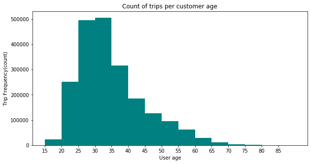

```python
binsize = 5
bins = np.arange(15, ford_gobike['user_age'].max()+binsize, binsize)

plt.figure(figsize=[10, 5])
plt.hist(data = ford_gobike, x = 'user_age', bins = bins, color = 'teal')
ticks = [15, 20, 25, 30, 35, 40, 45, 50, 55, 60, 65, 70, 75, 80, 85]

labels = ['{}'.format(val) for val in ticks]
plt.xticks(ticks, labels)

plt.title('Count of trips per customer age')
plt.xlabel('User age')
plt.ylabel('Trip Frequency(count)')
plt.show();
```

> The customer age distribution histogram shows that the most of the customers are between 25 and 35 years old.

Next, I will look at the trip frequency by the customer's gender.

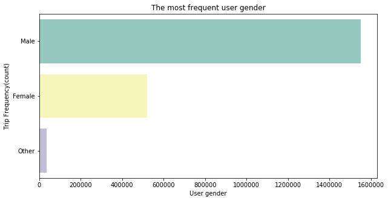

```python
plt.figure(figsize=[10, 5])
sb.countplot(data=ford_gobike, y='member_gender', palette = 'Set3');
plt.title('The most frequent user gender')
plt.xlabel('User gender')
plt.ylabel('Trip Frequency(count)')
plt.show();

#color = sb.color_palette()[9]
```

> Based on the above countplot we can clearly observe that the male customers are using Ford GoBikes 3 times more than women.

Next up, customers distribution by customer type.

[figure not shown]

```python
user_type_counts = ford_gobike['user_type'].value_counts()

plt.figure(figsize=[12, 6])

plt.subplot(1, 2, 1)
user_type_counts = ford_gobike['user_type'].value_counts()
sb.barplot(user_type_counts.index, user_type_counts)
plt.xticks(rotation=90)

for i in range (user_type_counts.shape[0]):
    count = user_type_counts[i]
    plt.text(i, count+1, count, ha = 'center', va= 'baseline', fontsize=12)

#data=ford_gobike, x='user_type', color = sb.color_palette()[2]);
plt.title('The most frequent user type')
plt.xlabel('User type')
plt.ylabel('Trip Frequency(count)')

plt.subplot(1, 2, 2)
plt.pie(user_type_counts, startangle = 30, autopct='%1.1f%%', pctdistance=0.75, labels=['Customer', 'Subscriber'], textprops={'color':'white'}, counterclock = False, wedgeprops = {'width' : 0.5});
plt.axis('square');
plt.title("Percentage of Trips by User Type")
plt.legend()
plt.show();
```

> From two plots we can see that most bike users are subscribers and just small slides are random customers. Probably the local people are most likely subscribers and tourists are customers.

Next below, exploration of travel variables.

### Exploration of TRAVEL variables

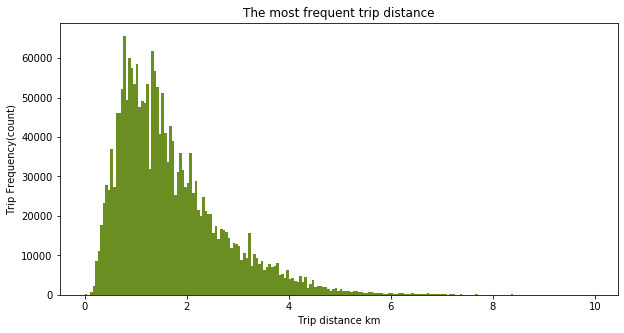

```python
# start with a standard-scaled plot
binsize = 0.01
bins = np.arange(0, 10, 0.05)
plt.figure(figsize=[10, 5])
plt.hist(data = ford_gobike, x = 'distance', bins = bins, color = 'olivedrab')

plt.title('The most frequent trip distance')
plt.xlabel('Trip distance km')
plt.ylabel('Trip Frequency(count)')
plt.show();
```

> Trip distance (km) has a long-tailed distribution. The distance distribution have peak between 0.5 and 1.5 km. Most of the customers have short distance trips.

Next up, trip duration (min) distribution.

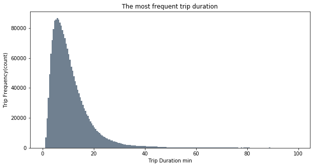

```python
# start with a standard-scaled plot
binsize = 1
bins = np.arange(0, 100, 1/2)
plt.figure(figsize=[10, 5])
plt.hist(data = ford_gobike, x = 'duration_min', bins = bins, color = 'slategrey')

plt.title('The most frequent trip duration')
plt.xlabel('Trip Duration min')
plt.ylabel('Trip Frequency(count)')
plt.show();
```

> From the above histogram we can see that the duration distribution is long-tailed with the peak around 5 minutes. Most of the trips take 5- 10 minutes.

Next up, trip speed distribution.

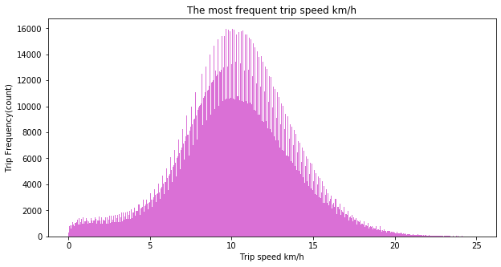

```python
binsize = 0.01
bins = np.arange(0, 25, 0.05)
plt.figure(figsize=[10, 5])
plt.hist(data = ford_gobike, x = 'speed km/h', bins = bins, color = 'orchid')

plt.title('The most frequent trip speed km/h')
plt.xlabel('Trip speed km/h')
plt.ylabel('Trip Frequency(count)')
plt.show();
```

> Based on histogram the bike trip speeds are most frequent to be at 10 km/h speed.

### Discuss the distribution(s) of your variable(s) of interest. Were there any unusual points? Did you need to perform any transformations?

- Exploration of time variables showed that customers used bikes most for travel to work and back on the workdays. The most interesting discovery, that bikes are used most during the spring and autumn season.
- Exploration of customer variables showed that customers are mostly young men between 25 and 35 who are locals and have Ford GoBikes subscriptions. Surprising fact that men are using bikes 3 times more than womens.
- Exploration of travel variables shows that customers usually have short trips and use small speed.

### Of the features you investigated, were there any unusual distributions? Did you perform any operations on the data to tidy, adjust, or change the form of the data? If so, why did you do this?

- For customer age, there was some false ages provided as there are ages until 141 years. I have eliminate the ages who are 2.5 times higher than the mean.
- The trip duration, distance and speed had long tales so I selected a range of data to elimite the tales to have a better visualization.

## Bivariate Exploration

> In this section, investigate relationships between pairs of variables in your data.

### Bivariate Exploration of TIME and CUSTOMER variables

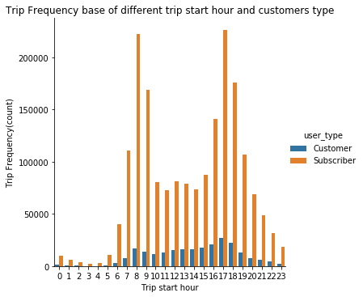

```python
sb.catplot(data = ford_gobike, x = 'start_hour', hue = 'user_type', kind = 'count')
plt.xlabel('Trip start hour')
plt.ylabel('Trip Frequency(count)')
plt.title('Trip Frequency base of different trip start hour and customers type')
plt.show();
```

> The frequency of bike trips based on customer type during the hours shows that subscribers use bikes mostly before working hours and after, but customers use bike rides during the day.

Next up, trip frequency base of different trip start weekday and customers type.

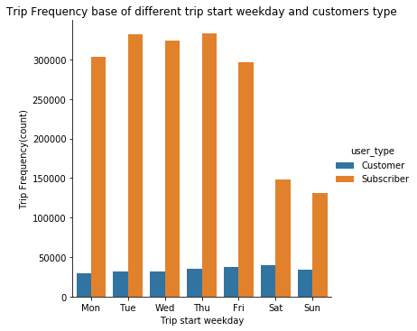

```python
order_d = ['Mon', 'Tue', 'Wed', 'Thu', 'Fri', 'Sat', 'Sun']
sb.catplot(data = ford_gobike, x = 'start_weekday', hue = 'user_type', kind = 'count', order = order_d)
plt.xlabel('Trip start weekday')
plt.ylabel('Trip Frequency(count)')
plt.title('Trip Frequency base of different trip start weekday and customers type')
plt.show();
```

> Based on the above plot we see that customers are usually tourists using bikes consistently during the week, but subscribers are usually locals using bikes more on weekdays and less on weekends.

Next up, trip frequency base of different trip start month and customers type.

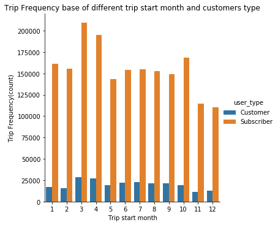

```python
sb.catplot(data = ford_gobike, x = 'start_month', hue = 'user_type', kind = 'count')
plt.xlabel('Trip start month')
plt.ylabel('Trip Frequency(count)')
plt.title('Trip Frequency base of different trip start month and customers type')
plt.show();
```

> This plot suggests that customers and subscribers use bikes similar during the year. The most popular months are March, April and October and less popular November and December.

Next below, bivariate exploration between customer type and gender variables.

### Bivariate Exploration between CUSTOMER variables

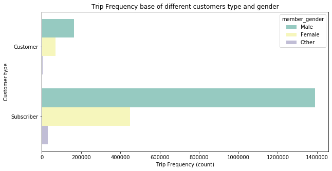

```python
plt.figure(figsize=[10, 5])

sb.countplot(data = ford_gobike, y = 'user_type', hue = 'member_gender', palette="Set3")
plt.title('Trip Frequency base of different customers type and gender')
plt.xlabel('Trip Frequency (count)')
plt.ylabel('Customer type')
plt.show();
```

> The plot above shows that the gender gap between customers is smaller than by subscribers. Which means that women are using bikes more as a tourist, but not for travel to work.

Next up, trip Frequency base of different user age and gender.

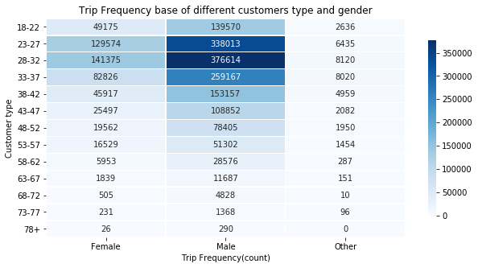

```python
binsize = 5

ct_counts = ford_gobike.groupby(['age_range', 'member_gender']).size()
ct_counts = ct_counts.reset_index(name='count')
ct_counts = ct_counts.pivot(index = 'age_range', columns = 'member_gender', values = 'count')

plt.figure(figsize=[10, 5])
sb.heatmap(ct_counts, annot = True, fmt = '.0f', cmap="Blues", cbar_kws={"shrink": .8}, linewidth=0.3)
plt.title('Trip Frequency base of different customers type and gender')
plt.xlabel('Trip Frequency(count)')
plt.ylabel('Customer type')
plt.show();
```

> This heatmap plot shows that the most of the customers are Male and between 28 and 32 years old.

Next up, bivariate exploration of customer and travel variables.

### Bivariate Exploration of USER and TRAVEL variables

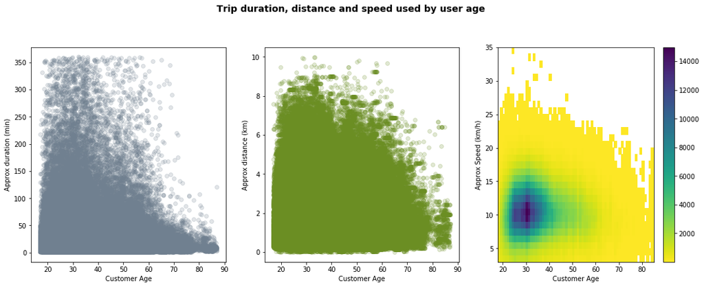

```python
plt.figure(figsize = [18, 6])

# PLOT ON LEFT
plt.subplot(1, 3, 1)
sb.regplot(data = ford_gobike[ford_gobike['duration_min']<360], x = 'user_age', y = 'duration_min', color = 'slategrey', x_jitter=1, scatter_kws={'alpha':1/5}, fit_reg=False)
plt.xlabel('Customer Age')
plt.ylabel('Approx duration (min)');

# PLOT ON CENTER
plt.subplot(1, 3, 2)
sb.regplot(data = ford_gobike[ford_gobike['distance']<10], x = 'user_age', y = 'distance', color = 'olivedrab', x_jitter=1, scatter_kws={'alpha':1/5}, fit_reg=False)
plt.xlabel('Customer Age')
plt.ylabel('Approx distance (km)');

# PLOT ON RIGHT
plt.subplot(1, 3, 3)

bins_x = np.arange(18, 85+1, 1)
bins_y = np.arange(3, 35+1, 1)

plt.hist2d(data = ford_gobike[ford_gobike['speed km/h']<35], x = 'user_age', y = 'speed km/h', cmin=0.5, cmap='viridis_r', bins = [bins_x, bins_y])
plt.colorbar()
plt.xlabel('Customer Age')
plt.ylabel('Approx Speed (km/h)')
plt.suptitle('Trip duration, distance and speed used by user age', y=1.03, fontsize=14, fontweight='semibold');
```

> These three plots show trips count by customer age and travel duration, distance and speed.It shows that younger users are those who take a longer bike trip, have longer distance and have a higher speed of the trip.

Next I will compare trip duration, distance and speed used by customer type.

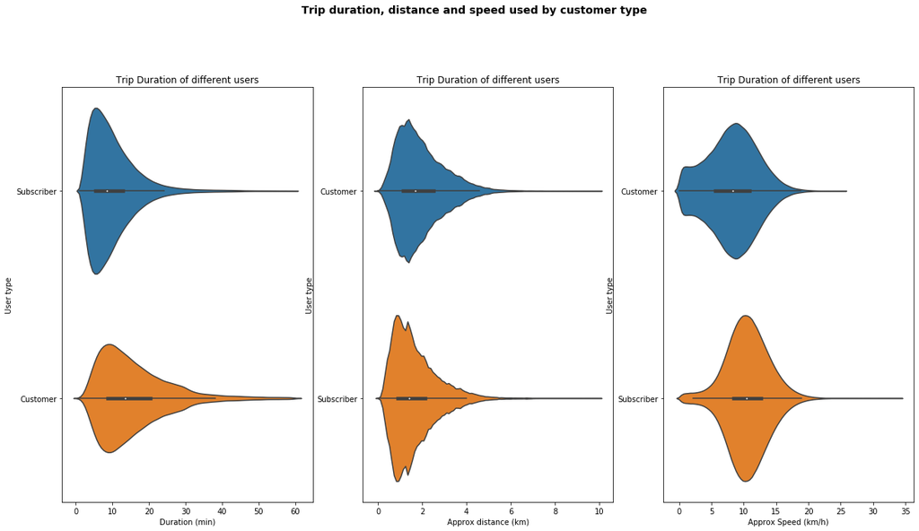

```python
plt.figure(figsize = [20, 10])

# PLOT ON LEFT
plt.subplot(1, 3, 1)
sb.violinplot(data=ford_gobike[ford_gobike['duration_min']<60], y='user_type', x='duration_min', innner=None)
plt.title('Trip Duration of different users')
plt.xlabel('Duration (min)')
plt.ylabel('User type')

# PLOT ON CENTER
plt.subplot(1, 3, 2)
sb.violinplot(data=ford_gobike[ford_gobike['distance']<10], y='user_type', x='distance', innner=None)
plt.title('Trip Duration of different users')
plt.xlabel('Approx distance (km)')
plt.ylabel('User type')

# PLOT ON RIGHT
plt.subplot(1, 3, 3)
sb.violinplot(data=ford_gobike[ford_gobike['speed km/h']<35], y='user_type', x='speed km/h', innner=None)
plt.title('Trip Duration of different users')
plt.xlabel('Approx Speed (km/h)')
plt.ylabel('User type')

plt.suptitle('Trip duration, distance and speed used by customer type', y=1.03, fontsize=14, fontweight='semibold');
```

Next up, trip duration, distance and speed used by customer gender.

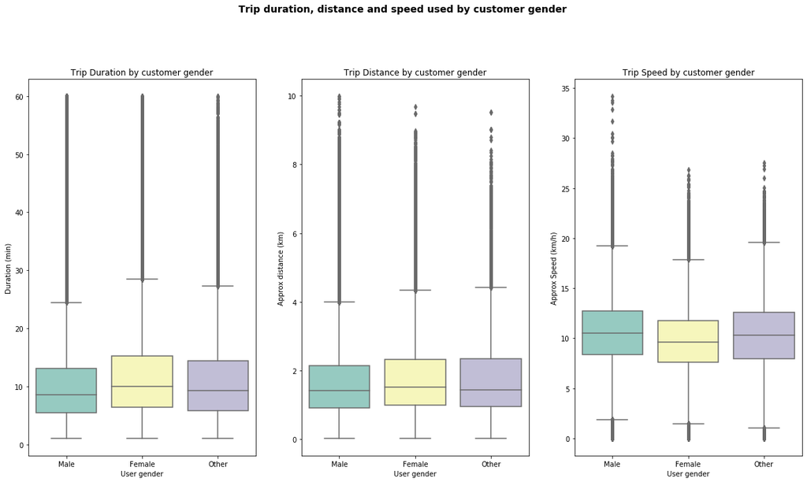

```python
plt.figure(figsize = [20, 10])

# PLOT ON LEFT
plt.subplot(1, 3, 1)
sb.boxplot(data=ford_gobike[ford_gobike['duration_min']<60], x='member_gender', y='duration_min', palette="Set3" )
plt.title('Trip Duration by customer gender')
plt.ylabel('Duration (min)')
plt.xlabel('User gender')

# PLOT ON CENTER
plt.subplot(1, 3, 2)
sb.boxplot(data=ford_gobike[ford_gobike['distance']<10], x='member_gender', y='distance', palette="Set3")
plt.title('Trip Distance by customer gender')
plt.ylabel('Approx distance (km)')
plt.xlabel('User gender')

# PLOT ON RIGHT
plt.subplot(1, 3, 3)
sb.boxplot(data=ford_gobike[ford_gobike['speed km/h']<35], x='member_gender', y='speed km/h', palette="Set3")
plt.title('Trip Speed by customer gender')
plt.ylabel('Approx Speed (km/h)')
plt.xlabel('User gender')

plt.suptitle('Trip duration, distance and speed used by customer gender', y=1.03, fontsize=14, fontweight='semibold');
```

> These three plots show trips count by customer gender and travel duration, distance and speed. It shows that females are more likely to use bikes with longer trip duration and have the lowest speed. Although the male user uses bikes for the shorter trip duration and has the highest speed.

### Did you observe any interesting relationships between the other features (not the main feature(s) of interest)?

> The plot trip frequency base of different customers type and gender shows that the gender gap between customers is smaller than by subscribers. Which means that women are using bikes more as a tourist, but not for travel to work. Also females are more likely to use bikes with longer trip duration.

## Multivariate Exploration

> Create plots of three or more variables to investigate your data even further.

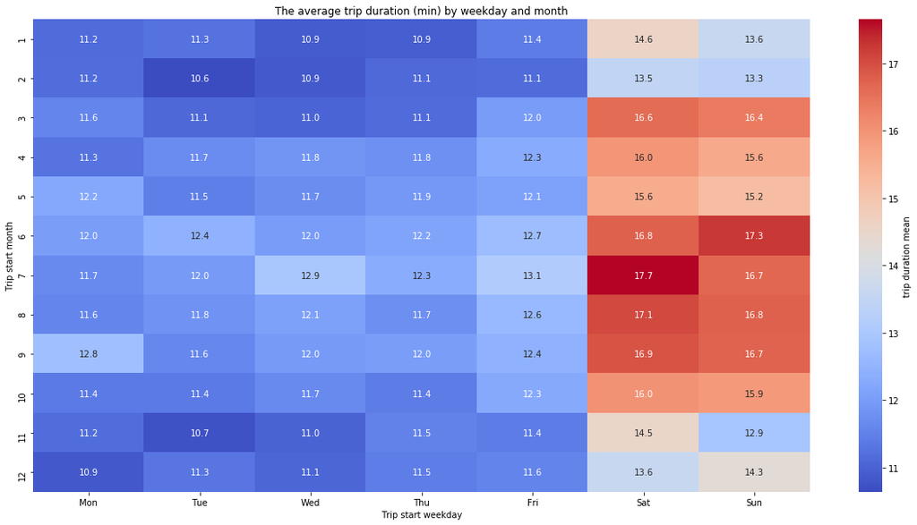

```python
df_new2 = pd.DataFrame(ford_gobike.groupby(['start_weekday', 'start_month']).mean()['duration_min'])
df_new2 = df_new2.reset_index()
df_new2.start_weekday = pd.Categorical(df_new2.start_weekday, categories=['Mon', 'Tue', 'Wed', 'Thu', 'Fri', 'Sat', 'Sun'], ordered=True)

pivot = df_new2.pivot_table(values='duration_min',index='start_month', columns='start_weekday')
plt.figure(figsize=(20,10))
sb.heatmap(pivot, annot=True, fmt='.1f', cbar_kws = {'label' : 'trip duration mean'}, cmap='coolwarm')
plt.xlabel('Trip start weekday')
plt.ylabel('Trip start month')
plt.title('The average trip duration (min) by weekday and month')
plt.show();
```

> Based on the heatmap above the trip duration means distribution is higher on weekend days and on summer months.

Next up, the average trip duration min by weekdays and hours.

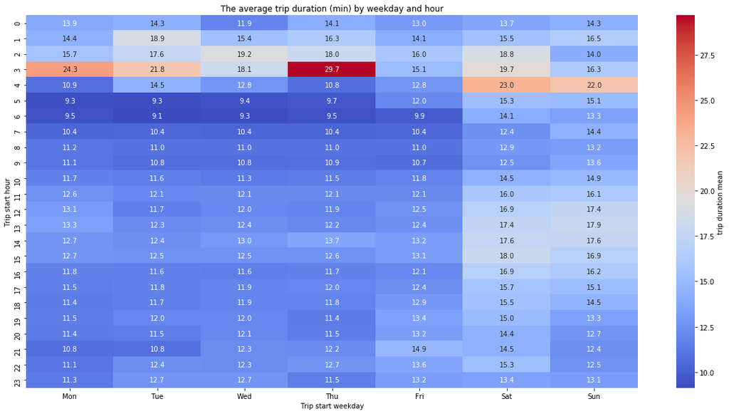

```python
weekdays = ['Mon', 'Tue', 'Wed', 'Thu', 'Fri', 'Sat', 'Sun']

group = ford_gobike.groupby(['start_weekday', 'start_hour'])
df_new3 = pd.DataFrame(group.mean()['duration_min'])
df_new3 = df_new3.reset_index()
df_new3.start_weekday = pd.Categorical(df_new3.start_weekday, categories = weekdays, ordered=True)

pivot = df_new3.pivot_table(values='duration_min',index='start_hour',columns='start_weekday')
plt.figure(figsize=(20,10))
sb.heatmap(pivot, annot=True, fmt='.1f', cbar_kws = {'label' : 'trip duration mean'}, cmap='coolwarm')
plt.xlabel('Trip start weekday')
plt.ylabel('Trip start hour')
plt.title('The average trip duration (min) by weekday and hour')
plt.show();
```

> The heatmap plot shows interesting facts that the highest average trip duration is at night time. It suggests that users use bikes when there is no public transport operating.

Next up, trip frequency base of different customers type, gender and age range.

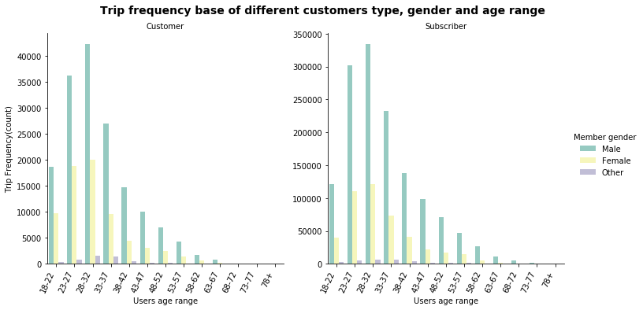

```python
g = sb.catplot(data=ford_gobike, x='age_range', col='user_type', hue='member_gender', kind='count', sharey = False, palette="Set3")
g.set_xticklabels(rotation=65, horizontalalignment='right')
g.set_axis_labels('Users age range', 'Trip Frequency(count)')
g._legend.set_title('Member gender')
g.set_titles("{col_name}")
g.fig.suptitle('Trip frequency base of different customers type, gender and age range', y=1.03, fontsize=14, fontweight='semibold');
```

> From the plot above we can have a more detailed look at the Ford GoBikes users. Compered distribution of bike trips by customer and subscriber types shows that the customer users are younger than subscribers users. Also the gender gaps are higher in subscriber type users.

Next up, compare distance, duration and user type.

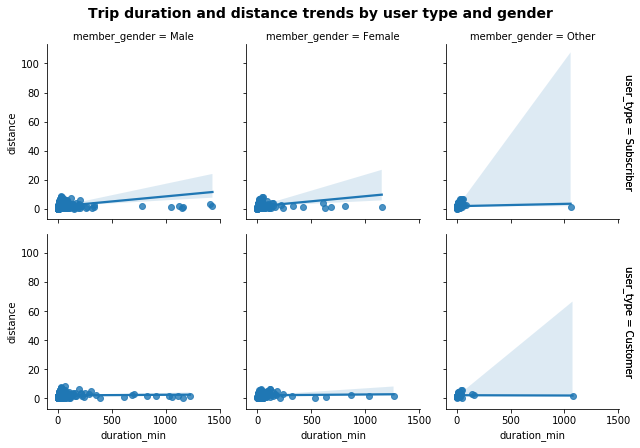

```python
# compare distance, duration and user type
sample = ford_gobike.sample(25000)
g = sb.FacetGrid(data = sample, col = 'member_gender', row = 'user_type', margin_titles = True)
g.map(sb.regplot, 'duration_min', 'distance')
g.set_titles('{col_name}');
g.fig.suptitle('Trip duration and distance trends by user type and gender', y=1.03, fontsize=14, fontweight='semibold');
```

### Were there any interesting or surprising interactions between features?

- The heatmap plot shows interesting facts that the highest average trip duration is at night time. It suggests that users use bikes when there is no public transport operating.

### List of resources

- Citi Bike 2017 Analysis - https://towardsdatascience.com/citi-bike-2017-analysis-efd298e6c22c
- Deriving the Haversine Formula - http://mathforum.org/library/drmath/view/51879.html
- Fast Haversine Approximation (Python/Pandas) - https://stackoverflow.com/questions/29545704/fast-haversine-approximation-python-pandas
- Rotating axis labels in matplotlib and seaborn - https://drawingfromdata.com/seaborn/matplotlib/visualization/2020/11/01/rotate-axis-labels-matplotlib-seaborn.html